# Homework 2 Report

## Name

Lauren Maurer

### Setup

Read in the data with `read_csv()` and store the data as an R object named `dataset`. Check the data to make sure all of the expected observations and variables are there.

```r
## Load the data and any necessary packages here.
dataset <- read.csv("maacs.csv.gz")
library(tidyverse)
```

```r
library(dplyr)
library(ggplot2)
```

## Part 1

We will first consider the relationship between FEV1 and age. In general, it is expected that as children get older (and hence, larger in size), their FEV1 values should get higher.

Consider the statement “FEV1 values in children are higher in older children relative to younger children”.

Write a function in R that takes the `dataset` object as an argument and returns `TRUE` if the statement above is true for the dataset and `FALSE` otherwise.

NOTE: In order to write this function, you will need to translate the statement above into something that can be checked with the data. There are many ways in which you can do that translation correctly and you only need to pick one way here.

NOTE: For this part, do not use any plots.

```r
## Write your function here

check_relationship <- function(data){
    dat <- dataset|>
      filter(!is.na(fev1))
    cor1 <- cor(dat$fev1, dat$age)
    if (cor1 > 0){
      return (TRUE)}
    else{
      return(FALSE)
    }
}

check_relationship(dataset)
```

```
## [1] TRUE
```

## Part 2

Fit a linear regression model with FEV1 as the outcome and age as a predictor.

How much does FEV1 change for a 1-year increase in the child’s age?

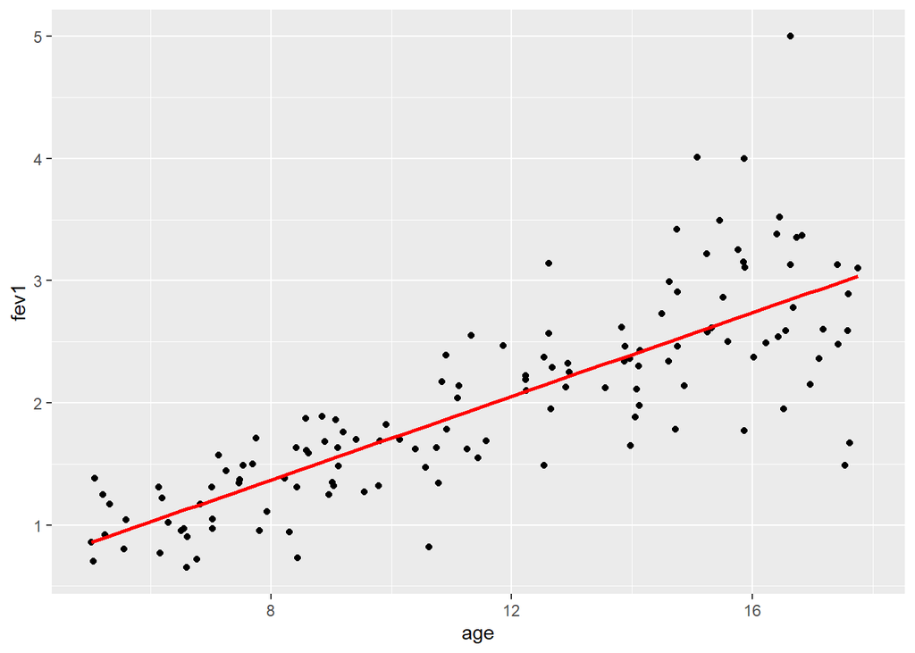

```r
## Add your code here
lm_model <- lm(fev1 ~ age, data = dataset)

ggplot(dataset, aes(x = age, y = fev1)) +
  geom_point() +
  geom_smooth(method = "lm", se = FALSE, color = "red")
```

Write your data analysis statement interpreting the regression model here:

The expected difference in FEV1 between children whose ages happens to differ by one year is 0.17 liters.

## Part 3

Develop **three** supporting premises derived from the data that support the statement you wrote in Part 2. These can be plots, other summary statistics, or model results.

NOTE:

- At least one supporting premise should use a plot.
- Do not use the code you write in Part 1 as a supporting premise

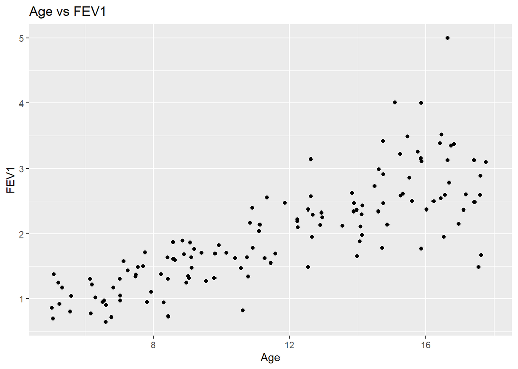

```r
## Add your code here

## Statement 1
ggplot(dataset, aes(x=age, y=fev1)) +
  geom_point() +
  labs(title = 'Age vs FEV1', x = 'Age', y = 'FEV1')
```

```r
## Statement 2
dataset_group <- dataset %>%
  mutate(age_group = cut(age,
                         breaks = c(5, 8, 11, 15, 18),
                         labels = c("5-7", "8-10", "11-14", "15-17"),
                         right = FALSE))
mean_table <- dataset_group %>%
  group_by(age_group) %>%
  summarise(
    mean_fev1 = round(mean(fev1, na.rm = TRUE), 3)
  )

tibble(mean_table)
```

```
## # A tibble: 4 × 2
##   age_group mean_fev1
##   <fct>         <dbl>
## 1 5-7            1.12
## 2 8-10           1.55
## 3 11-14          2.27
## 4 15-17          2.87
```

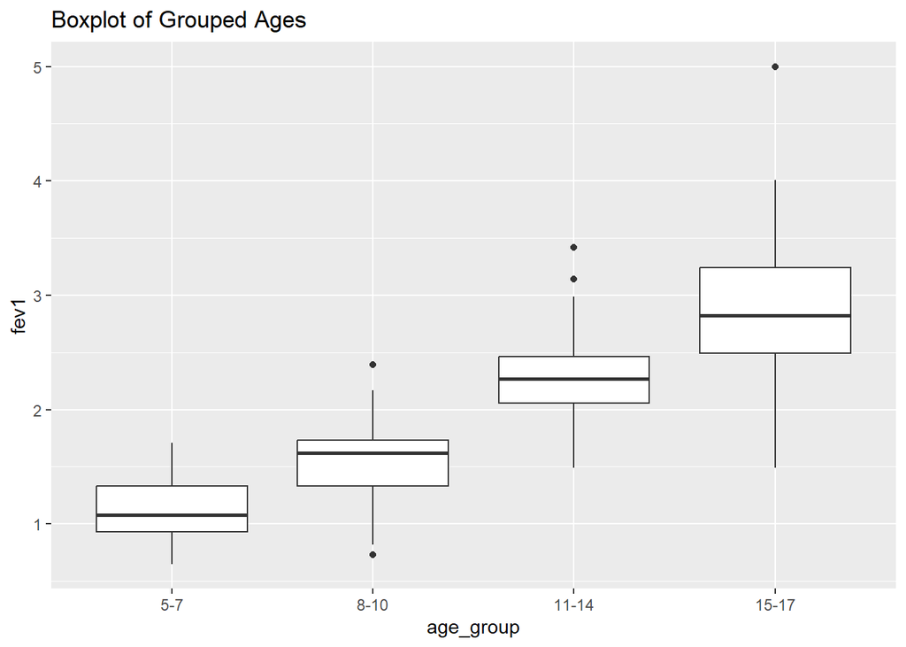

```r
## Statement 3
ggplot(dataset_group, aes(x=age_group, y= fev1)) +
  geom_boxplot() +
  labs(title = 'Boxplot of Grouped Ages')
```

Write the three supporting premise statements here:

1. The scatter plot of FEV1 versus age shows a clear positive slope, indicating that FEV1 tends to increase as age increases.
2. When ages are grouped into categories, the mean FEV1 values increase with each older age group.
3. Box plots of FEV1 stratified by age groups reveal that the median FEV1 values rise as children get older.

## Part 4

For each of the supporting premises above, write a function that takes the `dataset` object as an argument and returns `TRUE` if the supporting premise statement above is true for the dataset and `FALSE` otherwise.

For statements involving plots, instead of returning `TRUE` or `FALSE`, you function should do two things:

1. Produce the plot that is used in the statement
2. Produce a hypothetical version of the plot in the event that the statement is true. This can be done using simulated data or by simply hand drawing a plot.

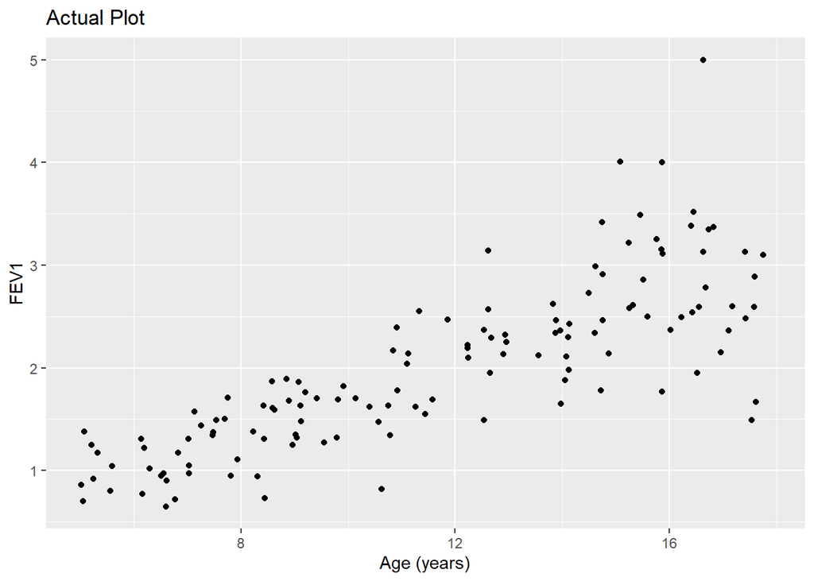

```r
## Function for supporting premise statement 1

# Plot used in statement
ggplot(dataset, aes(x=age, y=fev1)) +
  geom_point() +
  labs(title = "Actual Plot", x = "Age (years)", y = "FEV1")
```

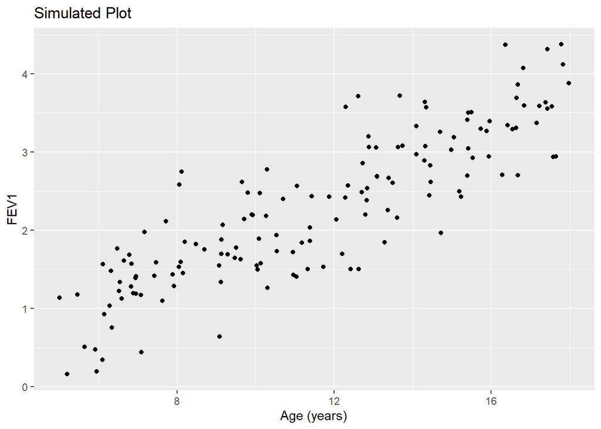

```r
# Hypothetical plot
x <- runif(150, min = 5, max = 18)  # Uniform distribution between 5 and 18
y <- x *.2 + rnorm(150, mean = 0, sd = .5)
y_ <- pmin(pmax(y, 0.5), 5)  # clamp y between 0.5 and 5
sim_data <- data.frame(age = x, fev1 = y)

ggplot(sim_data, aes(x = age, y = fev1)) +
  geom_point() +
  labs(title = "Simulated Plot", x = "Age (years)", y = "FEV1")
```

```r
## Function for supporting premise statement 2
statement2_function <- function(mean_table){
    mean_vec <- mean_table$mean_fev1

  # Check if the vector is strictly increasing
  is_increasing <- all(diff(mean_vec) > 0)

  return(is_increasing)
}

statement2_function(mean_table)
```

```
## [1] TRUE
```

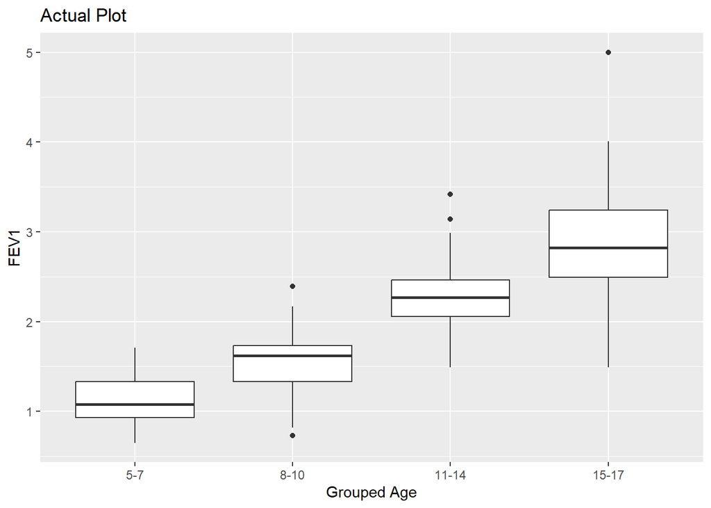

```r
## Function for supporting premise statement 3

# Real plot
ggplot(dataset_group, aes(x=age_group, y= fev1)) +
  geom_boxplot() +
  labs(title = "Actual Plot", x = "Grouped Age", y = "FEV1")
```

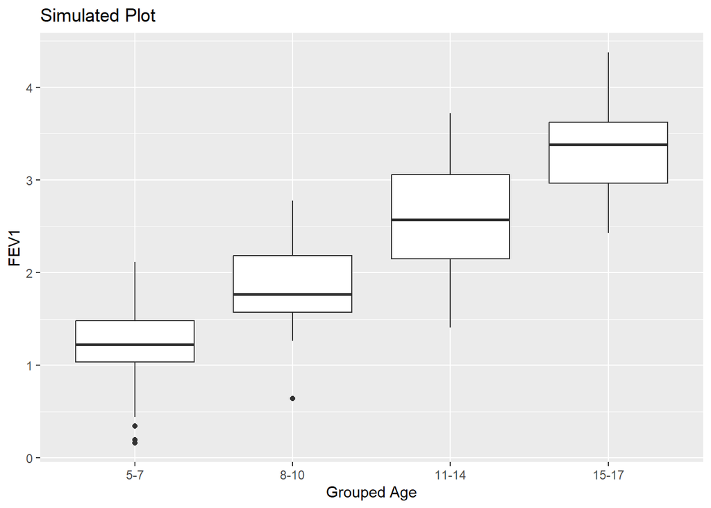

```r
# Simulated plot
sim_group <- sim_data %>%
  mutate(age_group = cut(age,
                         breaks = c(5, 8, 11, 15, 18),
                         labels = c("5-7", "8-10", "11-14", "15-17"),
                         right = FALSE))
sim_mean_table <- sim_group %>%
  group_by(age_group) %>%
  summarise(
    sim_mean_fev1 = round(mean(fev1, na.rm = TRUE), 3)
  )

ggplot(sim_group, aes(x=age_group, y=fev1)) +
  geom_boxplot() +
  labs(title = "Simulated Plot", x = "Grouped Age", y = "FEV1")
```

Execute each of your function and show that the produce the expected output.

## Part 5

Create a fault tree for the alternative outcome describing how the alternative outcome could be realized in the data even if the primary statement were true.

Your fault tree should be created as a separate image and does not need to be created in R. Upload the image of the fault tree to Canvas.